# Dictionary methods

Pablo Barbera

## Sentiment detection using dictionary methods

One of the most common applications of dictionary methods is sentiment analysis: using a dictionary of positive and negative words, we compute a sentiment score for each individual document.

Let’s apply this technique to tweets by the four leading candidates in the 2016 Presidential primaries. Which candidate was using positive rhetoric most frequently? Which candidate was most negative in their public messages on Twitter?

```r
library(quanteda)
tweets <- read.csv('candidate-tweets.csv', stringsAsFactors=F)
```

We will use the positive and negative categories in the augmented General Inquirer dictionary to measure the extent to which these candidates adopted a positive or negative tone during the election campaign.

Note that first you will need to install the `quanteda.dictionaries` package from GitHub

```r
devtools::install_github("kbenoit/quanteda.dictionaries")
```

First, we load the dictionary object. Note that we can apply the dictionary object directly (as we will see later), but for now let’s learn how to do this if we had a list of positive and negative words on a different file.

```r
library(quanteda.dictionaries)
data(data_dictionary_geninqposneg)

pos.words <- data_dictionary_geninqposneg[['positive']]
neg.words <- data_dictionary_geninqposneg[['negative']]
# a look at a random sample of positive and negative words
sample(pos.words, 10)
```

```
##  [1] "upright"     "responsive"  "authority"   "prestige"    "thankful"
##  [6] "picturesque" "main"        "accentuate"  "renovate"    "carefree"
```

```r
sample(neg.words, 10)
```

```
##  [1] "misunderstand" "falter"        "pitiless"      "flimsy"
##  [5] "marginal"      "dubious"       "unreliable"    "oppressive"
##  [9] "gash"          "brusque"
```

As earlier in the course, we will convert our text to a corpus object. Note that here `corpus` takes detects some metadata, which we will use later.

```r
twcorpus <- corpus(tweets)
```

Now we’re ready to run the sentiment analysis! First we will construct a dictionary object.

```r
mydict <- dictionary(list(positive = pos.words,
                          negative = neg.words))
```

And now we apply it to the corpus in order to count the number of words that appear in each category

```r
sent <- dfm(twcorpus, dictionary = mydict)
```

We can then extract the score and add it to the data frame as a new variable

```r
tweets$score <- as.numeric(sent[,1]) - as.numeric(sent[,2])
```

And now start answering some descriptive questions…

```r
# what is the average sentiment score?
mean(tweets$score)
```

```
## [1] 0.4775388
```

```r
# what is the most positive and most negative tweet?
tweets[which.max(tweets$score),]
```

```
##       screen_name
## 22177     tedcruz
##                                                                                                                                                       text
## 22177 We will restore our spirit. We will free our minds &amp; imagination. We will create a better world. We will bring back jobs, freedom &amp; security
##                  datetime
## 22177 2016-04-20 02:42:28
##                                                                   source
## 22177 <a href="http://twitter.com" rel="nofollow">Twitter Web Client</a>
##       lang score
## 22177   en     8
```

```r
tweets[which.min(tweets$score),]
```

```
##       screen_name
## 13843     tedcruz
##                                                                                                                                          text
## 13843 Can't win battle against radical Islamic terrorism if you're unwilling to utter words radical Islamic terrorism https://t.co/HASzpU0kuy
##                  datetime
## 13843 2014-06-18 03:02:50
##                                                                                    source
## 13843 <a href="https://about.twitter.com/products/tweetdeck" rel="nofollow">TweetDeck</a>
##       lang score
## 13843   en    -7
```

```r
# what is the proportion of positive, neutral, and negative tweets?
tweets$sentiment <- "neutral"
tweets$sentiment[tweets$score<0] <- "negative"
tweets$sentiment[tweets$score>0] <- "positive"
table(tweets$sentiment)
```

```
##
## negative  neutral positive
##     5258     8974    12503
```

We can also compute it at the candidate level by taking the average of the sentiment scores:

```r
# loop over candidates
candidates <- c("realDonaldTrump", "HillaryClinton", "tedcruz", "BernieSanders")

for (cand in candidates){
  message(cand, " -- average sentiment: ",
      round(mean(tweets$score[tweets$screen_name==cand]), 4)
    )
}
```

```
## realDonaldTrump -- average sentiment: 0.5394
```

```
## HillaryClinton -- average sentiment: 0.3785
```

```
## tedcruz -- average sentiment: 0.5277
```

```
## BernieSanders -- average sentiment: 0.3846
```

But what happens if we now run the analysis excluding a single word?

```r
pos.words <- pos.words[-which(pos.words=="great")]

mydict <- dictionary(list(positive = pos.words,
                          negative = neg.words))
sent <- dfm(twcorpus, dictionary = mydict)
tweets$score <- as.numeric(sent[,1]) - as.numeric(sent[,2])

for (cand in candidates){
  message(cand, " -- average sentiment: ",
      round(mean(tweets$score[tweets$screen_name==cand]), 4)
    )
}
```

```
## realDonaldTrump -- average sentiment: 0.3913
```

```
## HillaryClinton -- average sentiment: 0.3596
```

```
## tedcruz -- average sentiment: 0.4996
```

```
## BernieSanders -- average sentiment: 0.3727
```

How would we normalize by text length? (Maybe not necessary here given that tweets have roughly the same length.)

```r
# collapse by account into 4 documents
twdfm <- dfm(twcorpus, groups = "screen_name")
twdfm
```

```
## Document-feature matrix of: 4 documents, 43,426 features (66.9% sparse).
```

```r
# turn word counts into proportions
twdfm[1:4, 1:10]
```

```
## Document-feature matrix of: 4 documents, 10 features (30.0% sparse).
## 4 x 10 sparse Matrix of class "dfm"
##                  features
## docs                rt @geraldorivera     : recruit @realdonaldtrump   to
##   BernieSanders   1018              0  4186       0               11 2407
##   HillaryClinton  1449              0  7800       0               33 3389
##   realDonaldTrump  607              8  7138       2             2278 2537
##   tedcruz         4464              0 18871       3              203 4045
##                  features
## docs              finish that horrid eyesore
##   BernieSanders        0  747      0       0
##   HillaryClinton       5  561      0       0
##   realDonaldTrump      7  714      2       1
##   tedcruz              6  429      0       0
```

```r
twdfm <- dfm_weight(twdfm, scheme="prop")
twdfm[1:4, 1:10]
```

```
## Document-feature matrix of: 4 documents, 10 features (30.0% sparse).
## 4 x 10 sparse Matrix of class "dfm"
##                  features
## docs                       rt @geraldorivera          :      recruit
##   BernieSanders   0.010252175   0            0.04215678 0
##   HillaryClinton  0.009177857   0            0.04940461 0
##   realDonaldTrump 0.003413027   4.498223e-05 0.04013540 1.124556e-05
##   tedcruz         0.018250652   0            0.07715234 1.226522e-05
##                  features
## docs              @realdonaldtrump         to       finish        that
##   BernieSanders       0.0001107799 0.02424065 0            0.007522962
##   HillaryClinton      0.0002090195 0.02146567 3.166962e-05 0.003553332
##   realDonaldTrump     0.0128086906 0.01426499 3.935945e-05 0.004014664
##   tedcruz             0.0008299468 0.01653761 2.453045e-05 0.001753927
##                  features
## docs                    horrid      eyesore
##   BernieSanders   0            0
##   HillaryClinton  0            0
##   realDonaldTrump 1.124556e-05 5.622779e-06
##   tedcruz         0            0
```

```r
# Apply dictionary using `dfm_lookup()` function:
sent <- dfm_lookup(twdfm, dictionary = mydict)
sent
```

```
## Document-feature matrix of: 4 documents, 2 features (0.0% sparse).
## 4 x 2 sparse Matrix of class "dfm"
##                  features
## docs                positive   negative
##   BernieSanders   0.04752457 0.03241822
##   HillaryClinton  0.03968204 0.02666582
##   realDonaldTrump 0.04790045 0.03129639
##   tedcruz         0.03777689 0.01847551
```

```r
(sent[,1]-sent[,2])*100
```

```
## 4 x 1 sparse Matrix of class "dgCMatrix"
##                  features
## docs              positive
##   BernieSanders   1.510635
##   HillaryClinton  1.301621
##   realDonaldTrump 1.660407
##   tedcruz         1.930137
```

Finally, let’s apply a different dictionary so that we can practice with dictionaries in different formats:

```r
data(data_dictionary_MFD)
# dictionary keys
names(data_dictionary_MFD)
```

```
##  [1] "care.virtue"      "care.vice"        "fairness.virtue"
##  [4] "fairness.vice"    "loyalty.virtue"   "loyalty.vice"
##  [7] "authority.virtue" "authority.vice"   "sanctity.virtue"
## [10] "sanctity.vice"
```

```r
# looking at words within first key
data_dictionary_MFD$care.virtue[1:10]
```

```
##  [1] "alleviate"   "alleviated"  "alleviates"  "alleviating" "alleviation"
##  [6] "altruism"    "altruist"    "beneficence" "beneficiary" "benefit"
```

```r
# applying dictionary
# 1) collapse by account
twdfm <- dfm(twcorpus, groups = "screen_name")
# 2) turn words into proportions
twdfm <- dfm_weight(twdfm, scheme="prop")
# 3) apply dictionary
moral <- dfm_lookup(twdfm, dictionary = data_dictionary_MFD)

# are liberals more sensitive to care and virtue?
sort(moral[,'care.virtue']*100)
```

```
## <sparse>[ <logic> ] : .M.sub.i.logical() maybe inefficient
```

```
## Document-feature matrix of: 4 documents, 1 feature (0.0% sparse).
## 4 x 1 sparse Matrix of class "dfm"
##                  features
## docs              care.virtue
##   tedcruz           0.2342658
##   realDonaldTrump   0.2890108
##   HillaryClinton    0.6758297
##   BernieSanders     0.6858282
```

```r
sort(moral[,'fairness.virtue']*100)
```

```
## <sparse>[ <logic> ] : .M.sub.i.logical() maybe inefficient
```

```
## Document-feature matrix of: 4 documents, 1 feature (0.0% sparse).
## 4 x 1 sparse Matrix of class "dfm"
##                  features
## docs              fairness.virtue
##   realDonaldTrump      0.08321713
##   tedcruz              0.12633180
##   BernieSanders        0.23666613
##   HillaryClinton       0.32683050
```

```r
# are conservatives more sensitive to sanctity and authority?
sort(moral[,'sanctity.virtue']*100)
```

```
## <sparse>[ <logic> ] : .M.sub.i.logical() maybe inefficient
```

```
## Document-feature matrix of: 4 documents, 1 feature (0.0% sparse).
## 4 x 1 sparse Matrix of class "dfm"
##                  features
## docs              sanctity.virtue
##   BernieSanders        0.09265227
##   HillaryClinton       0.09564226
##   realDonaldTrump      0.10570825
##   tedcruz              0.19624357
```

```r
sort(moral[,'authority.virtue']*100)
```

```
## <sparse>[ <logic> ] : .M.sub.i.logical() maybe inefficient
```

```
## Document-feature matrix of: 4 documents, 1 feature (0.0% sparse).
## 4 x 1 sparse Matrix of class "dfm"
##                  features
## docs              authority.virtue
##   BernieSanders          0.4350628
##   HillaryClinton         0.4769445
##   tedcruz                0.5535704
##   realDonaldTrump        0.5583420
```

## Identifying most unique features of documents

*Keyness* is a measure of to what extent some features are specific to a (group of) document in comparison to the rest of the corpus, taking into account that some features may be too rare.

```r
twdfm <- dfm(twcorpus, groups=c("screen_name"), verbose=TRUE)
```

```
## Creating a dfm from a corpus input...
```

```
##    ... lowercasing
```

```
##    ... found 26,735 documents, 43,426 features
```

```
##    ... grouping texts
```

```
##    ... created a 4 x 43,426 sparse dfm
##    ... complete.
## Elapsed time: 1.86 seconds.
```

```r
# Donald Trump
head(textstat_keyness(twdfm, target="realDonaldTrump",
                      measure="chi2"), n=20)
```

```
##                   feature      chi2 p n_target n_reference
## 1                       " 7614.8228 0     6457        3616
## 2        @realdonaldtrump 5381.1953 0     2278         247
## 3                       ! 4049.1884 0     5173        4277
## 4                   trump 2570.4147 0     1549         511
## 5              #trump2016 1937.3961 0      686           0
## 6                   great 1722.0145 0     1117         421
## 7  #makeamericagreatagain 1465.3955 0      519           0
## 8                       i  883.7211 0     1769        1953
## 9                   again  647.8184 0      385         123
## 10                     he  635.0352 0      686         487
## 11                 donald  634.4037 0      509         262
## 12                   will  633.2637 0     1160        1216
## 13                  thank  612.6007 0      701         524
## 14                    you  602.2376 0     1893        2590
## 15                   poll  552.9859 0      344         120
## 16                      -  455.1203 0     1216        1550
## 17                   @cnn  438.2103 0      207          36
## 18                    run  429.4179 0      205          37
## 19                    jeb  399.5410 0      176          23
## 20                     so  379.0986 0      509         433
```

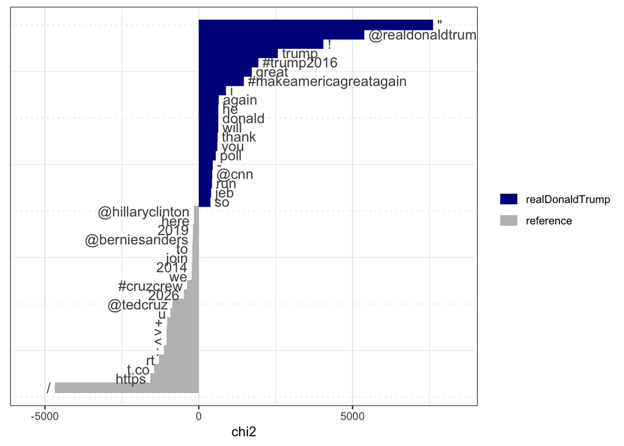

```r
textstat_keyness(twdfm, target="realDonaldTrump",
                      measure="chi2") %>% textplot_keyness()
```

```r
# Hillary Clinton
head(textstat_keyness(twdfm, target="HillaryClinton",
                      measure="chi2"), n=20)
```

```
##             feature      chi2 p n_target n_reference
## 1           hillary 3173.4500 0     1402         351
## 2                 < 2328.2650 0     2913        2943
## 3                 > 2328.2650 0     2913        2943
## 4                 + 2308.3517 0     2935        3000
## 5                 u 2245.8672 0     2921        3034
## 6              2014 1859.8423 0      779         166
## 7                 h 1072.1154 0      382          40
## 8   @hillaryclinton 1047.9076 0      470         122
## 9  @thebriefing2016  836.3876 0      253           0
## 10             2019  699.1078 0      754         676
## 11     #hillary2016  680.9641 0      206           0
## 12        hillary's  590.9815 0      194          10
## 13       #imwithher  512.3375 0      155           0
## 14    @hillaryfornh  446.2163 0      135           0
## 15              her  437.9556 0      332         211
## 16         families  408.1788 0      255         126
## 17                s  398.0471 0      406         347
## 18              gun  387.4441 0      164          36
## 19    @hillaryforia  340.4305 0      103           0
## 20       #demdebate  338.4354 0      258         165
```

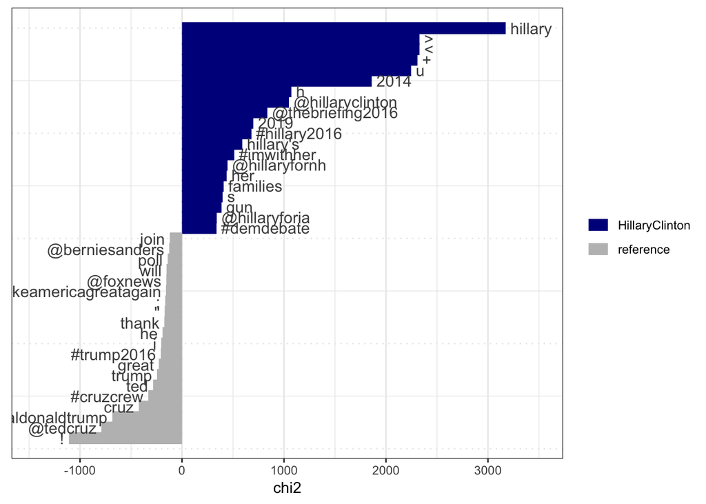

```r
textstat_keyness(twdfm, target="HillaryClinton",
                      measure="chi2") %>% textplot_keyness()
```

```r
# Ted Cruz
head(textstat_keyness(twdfm, target="tedcruz",
                      measure="chi2"), n=20)
```

```
##           feature      chi2 p n_target n_reference
## 1               / 6042.9827 0    29820       29005
## 2        @tedcruz 4513.0431 0     2607          38
## 3               : 3267.9287 0    18871       19124
## 4       #cruzcrew 1937.9619 0     1090           1
## 5            t.co 1825.5720 0     9569        9301
## 6              rt 1785.5427 0     4464        3074
## 7           https 1527.6928 0     7569        7197
## 8            cruz 1408.2260 0     1226         256
## 9             ted 1034.7004 0      855         157
## 10           2026 1014.7150 0     1393         589
## 11           join  671.1111 0      786         274
## 12    #choosecruz  537.3625 0      302           0
## 13 #cruztovictory  439.4629 0      247           0
## 14   @teamtedcruz  423.4445 0      238           0
## 15   #cruzcountry  414.5456 0      233           0
## 16           http  402.8215 0     2674        2786
## 17        liberty  283.1700 0      181          11
## 18   conservative  277.3195 0      185          15
## 19  #makedclisten  275.7390 0      155           0
## 20      #cruz2016  275.7390 0      155           0
```

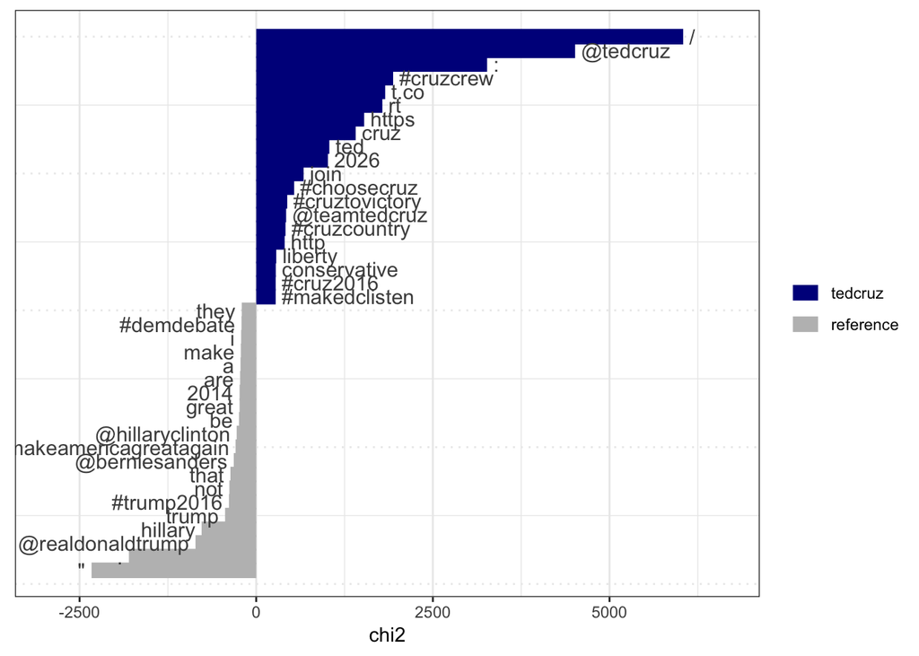

```r
textstat_keyness(twdfm, target="tedcruz",
                      measure="chi2") %>% textplot_keyness()
```

```r
# Bernie Sanders
head(textstat_keyness(twdfm, target="BernieSanders",
                      measure="chi2"), n=20)
```

```
##           feature      chi2 p n_target n_reference
## 1  @berniesanders 3025.6940 0      553          28
## 2          bernie 1602.0880 0      329          47
## 3      revolution  784.9614 0      148          11
## 4    #feelthebern  775.5139 0      134           1
## 5         sanders  747.3600 0      186          57
## 6              we  672.1012 0     1210        3012
## 7       political  648.5265 0      200         101
## 8             not  646.6276 0      637        1137
## 9          street  521.2746 0      162          83
## 10           that  496.3863 0      747        1704
## 11              .  477.4912 0     4861       20202
## 12           wall  462.4595 0      175         124
## 13           must  421.2365 0      253         306
## 14         people  403.6589 0      448         862
## 15         change  368.5093 0      175         166
## 16   billionaires  351.8531 0       76          14
## 17            and  350.0464 0     1506        5134
## 18       #notmeus  339.0021 0       58           0
## 19        poverty  335.1252 0       74          15
## 20    billionaire  315.5050 0       59           4
```

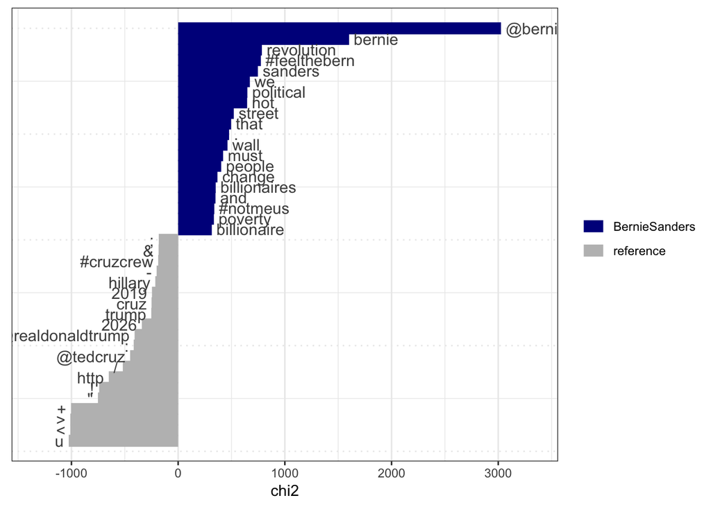

```r
textstat_keyness(twdfm, target="BernieSanders",
                      measure="chi2") %>% textplot_keyness()
```

If we have other metadata in our corpus, we can also use it to identify words whose usage varies over time:

```r
trump <- corpus_subset(twcorpus, screen_name=="realDonaldTrump")
twdfm <- dfm(trump, remove_punct=TRUE,
             remove=c(stopwords("english"), 'rt', 'u', 's'), verbose=TRUE)
```

```
## Creating a dfm from a corpus input...
```

```
##    ... lowercasing
```

```
##    ... found 7,546 documents, 15,304 features
```

```
##    ... removed 170 features
##    ... created a 7,546 x 15,134 sparse dfm
##    ... complete.
## Elapsed time: 0.478 seconds.
```

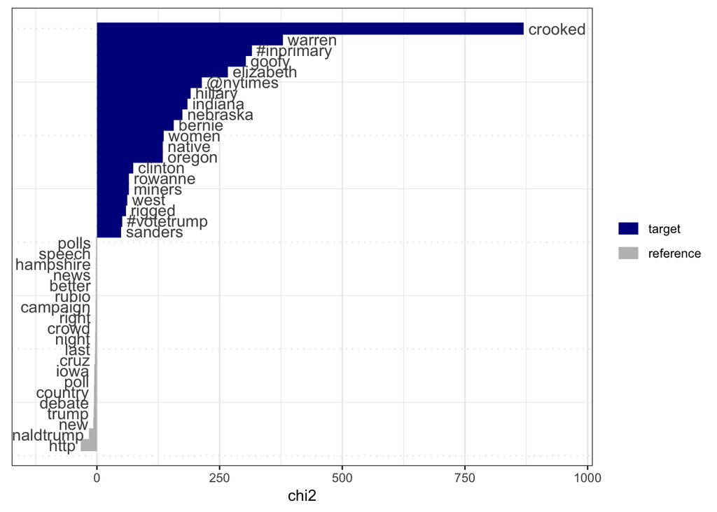

```r
textstat_keyness(twdfm, target=docvars(twdfm)$datetime>"2016-05",
                      measure="chi2") %>% textplot_keyness()
```